# Using proteus R package: TMT data

Marek Gierlinski

This tutorial demonstrates how to analyse data from TMT MS/MS experiment in *Proteus*. We strongly suggest the user should read the main tutorial first and familiarize themselves with the package.

```r
vignette("proteus")
```

Here, we are only going to point out the differences between label-free and TMT analysis. For this, we use data from [Crozier et al. 2018](http://www.mcponline.org/content/17/6/1184), Pride accession PXD008741. These data are distributed in a separate package *proteusTMT*, which needs loading first:

```r
library(proteusTMT)
data(proteusTMT)
```

# 1 Input data

## 1.1 Columns in evidence file

The default `measure.cols` object is designed for label-free data. For TMT data we need to specify all reporter intensity columns. In out example we have 10 reporter columns, numbered from 0 to 9:

```r
measCols <- paste0("Reporter intensity ", 0:9)
names(measCols) <- paste0("reporter_", 0:9)
```

The resulting object is

```r
str(as.list(measCols))
```

```
## List of 10
##  $ reporter_0: chr "Reporter intensity 0"
##  $ reporter_1: chr "Reporter intensity 1"
##  $ reporter_2: chr "Reporter intensity 2"
##  $ reporter_3: chr "Reporter intensity 3"
##  $ reporter_4: chr "Reporter intensity 4"
##  $ reporter_5: chr "Reporter intensity 5"
##  $ reporter_6: chr "Reporter intensity 6"
##  $ reporter_7: chr "Reporter intensity 7"
##  $ reporter_8: chr "Reporter intensity 8"
##  $ reporter_9: chr "Reporter intensity 9"
```

We are going to use the default `evidenceColumns` object, but the user should carefully check that the column names correspond to those in the evidence file.

## 1.2 Read evidence file

Due to its large size we do not attach the TMT evidence file to this package. The command to read the file would be:

```r
evi <- readEvidenceFile(evidenceFile, measure.cols=measCols)
```

We do attach an example processed evidence data with the package, it is called `evi`. It contains all reported intensity columns:

```r
head(evi)
```

```
##        sequence modified_sequence protein_group      proteins
## 1 AAAAAASVGSSNK   _AAAAAASVGSSNK_    Unmodified   Tb927.1.840
## 2  AAAAALLSALLR    _AAAAALLSALLR_    Unmodified Tb927.10.1310
## 3  AAAAALLSALLR    _AAAAALLSALLR_    Unmodified Tb927.10.1310
## 4  AAAAALLSALLR    _AAAAALLSALLR_    Unmodified Tb927.10.1310
## 5  AAAAALLSALLR    _AAAAALLSALLR_    Unmodified Tb927.10.1310
## 6  AAAAALLSALLR    _AAAAALLSALLR_    Unmodified Tb927.10.1310
##         protein experiment charge reverse contaminant reporter_0
## 1   Tb927.1.840      E5016      2                             NA
## 2 Tb927.10.1310      E5015      2                        4079.90
## 3 Tb927.10.1310      E5015      3                        1201.50
## 4 Tb927.10.1310      E5016      2                        1075.00
## 5 Tb927.10.1310      E5016      3                         594.79
## 6 Tb927.10.1310      E5014      2                         961.38
##   reporter_1 reporter_2 reporter_3 reporter_4 reporter_5 reporter_6
## 1         NA     45.638     190.24     83.692     55.347         NA
## 2     5038.5   8193.700   10170.00   8853.500   7637.100    7555.20
## 3     1824.5   3049.600    4098.00   3595.300   2940.000    3060.60
## 4     3102.3   2391.800    2790.30   3421.500   2874.200    3057.50
## 5     1756.6   1663.700    1874.20   1809.300   1547.000    1719.60
## 6     1533.8   1059.900    1097.10    929.030   1036.400     729.57
##   reporter_7 reporter_8 reporter_9
## 1     117.83     109.15      69.12
## 2    5632.60    5961.00    6240.70
## 3    2111.50    2433.60    2748.20
## 4    2392.30    3070.20    3067.40
## 5    1443.40    1905.20    1884.00
## 6    1179.10     872.27     557.23
```

## 1.3 Metadata

Metadata for this experiment needs to specify all the reporter columns, experiments and corresponding condition and replicates:

```r
metadataFile <- system.file("extdata", "metadata.txt", package="proteusTMT")
meta <- read.delim(metadataFile, header=TRUE, sep="\t")
```

```r
meta
```

```
##    experiment              measure sample condition replicate
## 1       E5014 Reporter intensity 0 CTRL-1      CTRL         1
## 2       E5015 Reporter intensity 0 CTRL-2      CTRL         2
## 3       E5016 Reporter intensity 0 CTRL-3      CTRL         3
## 4       E5014 Reporter intensity 1 T0.5-1      T0.5         1
## 5       E5015 Reporter intensity 1 T0.5-2      T0.5         2
## 6       E5016 Reporter intensity 1 T0.5-3      T0.5         3
## 7       E5014 Reporter intensity 2   T3-1        T3         1
## 8       E5015 Reporter intensity 2   T3-2        T3         2
## 9       E5016 Reporter intensity 2   T3-3        T3         3
## 10      E5014 Reporter intensity 3   T5-1        T5         1
## 11      E5015 Reporter intensity 3   T5-2        T5         2
## 12      E5016 Reporter intensity 3   T5-3        T5         3
## 13      E5014 Reporter intensity 4   T6-1        T6         1
## 14      E5015 Reporter intensity 4   T6-2        T6         2
```

[output cut: 16 more lines]

## 1.4 No ‘Experiment’ column?

It is possible to run *MaxQuant* for one experiment where conditions are encoded in reporter columns only. In this case the evidence file will not contain the column ‘Experiment’. *Proteus* can deal with such configuration. All you need is to remove the ‘experiment’ field from the default column list:

```r
eviCols <- evidenceColumns
eviCols$experiment <- NULL
```

and read evidence file with an additional argument:

```r
evi <- readEvidenceFile(evidenceFile, measure.cols=measCols, data.cols = eviCols)
```

The ‘Experiment’ column will be skipped. Obviously, metadata should not contain ‘Experiment’ column either.

Please note that in such case peptide and protein objects created by *Proteus* will contain a metadata data frame (`metadata` field in the object, see, e.g., `pepdat$metadata`) with column `experiment` filled with dummy values. This is done for consistent internal processing. OK, we are lazy and it was easier to do it this way.

# 2 Peptide data

## 2.1 Create a peptide dataset

We chose the median to aggregate peptide intensities from multiple entries in the evidence data:

```r
pepdat <- makePeptideTable(evi, meta, measure.cols=measCols, aggregate.fun=aggregateMedian, experiment.type="TMT")
```

We can use generic `summary` function to see more information about `pepdat`.

```r
summary(pepdat)
```

```
##
## *** Basic statistics ***
##
##   content = peptide
##   experiment type = TMT
##   number of samples = 30
##   number of conditions = 10
##   number of peptides = 42381
##   samples = CTRL-1, CTRL-2, CTRL-3, T0.5-1, T0.5-2, T0.5-3, T3-1, T3-2, T3-3, T5-1, T5-2, T5-3, T6-1, T6-2, T6-3, T7-1, T7-2, T7-3, T8-1, T8-2, T8-3, T9-1, T9-2, T9-3, T10-1, T10-2, T10-3, T11-1, T11-2, T11-3
##   conditions = CTRL, T0.5, T10, T11, T3, T5, T6, T7, T8, T9
##
## *** Data processing ***
##
##   evidence columns used = Reporter intensity 0, Reporter intensity 1, Reporter intensity 2, Reporter intensity 3, Reporter intensity 4, Reporter intensity 5, Reporter intensity 6, Reporter intensity 7, Reporter intensity 8, Reporter intensity 9
##   sequence = 'Sequence'
##   protein = 'Leading razor protein'
##   normalization = identity
```

## 2.2 Number of peptides

This is the number of non-zero peptide intensities per sample.

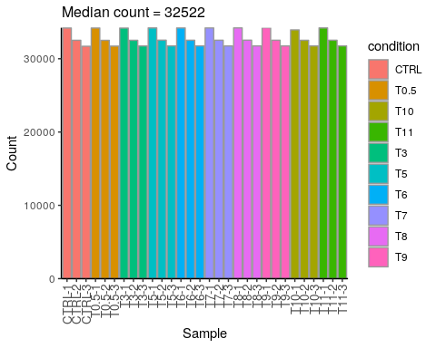

```r
plotCount(pepdat)
```

# 3 Protein data

## 3.1 Create protein dataset

We create protein data using the high-flyer method.

```r
prodat <- makeProteinTable(pepdat, aggregate.fun=aggregateHifly, hifly=3)
```

Again, we can use a generic `summary` function to see its properties.

```r
summary(prodat)
```

```
##
## *** Basic statistics ***
##
##   content = protein
##   experiment type = TMT
##   number of samples = 30
##   number of conditions = 10
##   number of proteins = 5772
##   samples = CTRL-1, CTRL-2, CTRL-3, T0.5-1, T0.5-2, T0.5-3, T3-1, T3-2, T3-3, T5-1, T5-2, T5-3, T6-1, T6-2, T6-3, T7-1, T7-2, T7-3, T8-1, T8-2, T8-3, T9-1, T9-2, T9-3, T10-1, T10-2, T10-3, T11-1, T11-2, T11-3
##   conditions = CTRL, T0.5, T10, T11, T3, T5, T6, T7, T8, T9
##
## *** Data processing ***
##
##   evidence columns used = Reporter intensity 0, Reporter intensity 1, Reporter intensity 2, Reporter intensity 3, Reporter intensity 4, Reporter intensity 5, Reporter intensity 6, Reporter intensity 7, Reporter intensity 8, Reporter intensity 9
##   sequence = 'Sequence'
##   protein = 'Leading razor protein'
##   normalization = identity
##
## *** Protein data ***
##
##   quantification method =
##   minimum number of peptides per protein = 2
```

## 3.2 Normalization

For TMT data we recommend using CONSTANd normalization [Maes et al. 2016](https://www.ncbi.nlm.nih.gov/pmc/articles/PMC4974351/pdf/zjw2779.pdf).

```r
prodat.norm <- normalizeTMT(prodat)
```

These two figures show reporter intensity distributions before and after normalization.

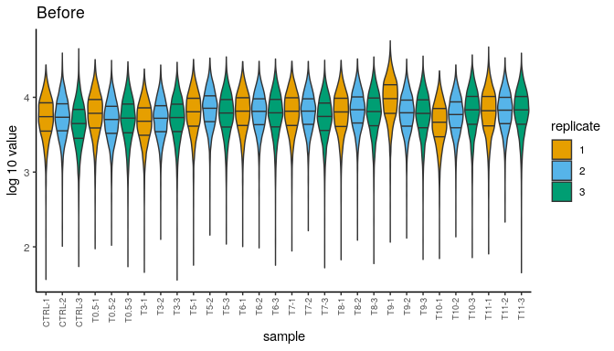

```r
plotSampleDistributions(prodat, fill="replicate") + labs(title="Before")
```

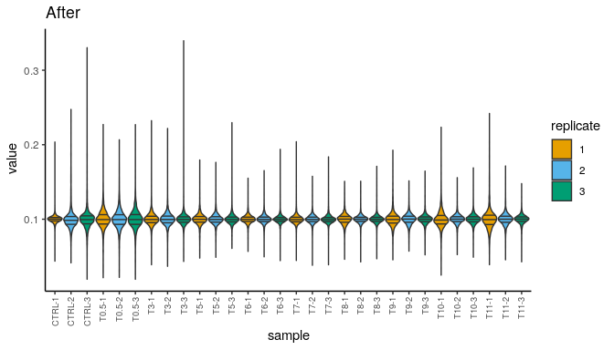

```r
plotSampleDistributions(prodat.norm, log.scale=FALSE, fill="replicate") + labs(title="After")
```

## 3.3 Protein clustering

We can use the same function `plotClustering()` to see the dendrogram for the proteins.

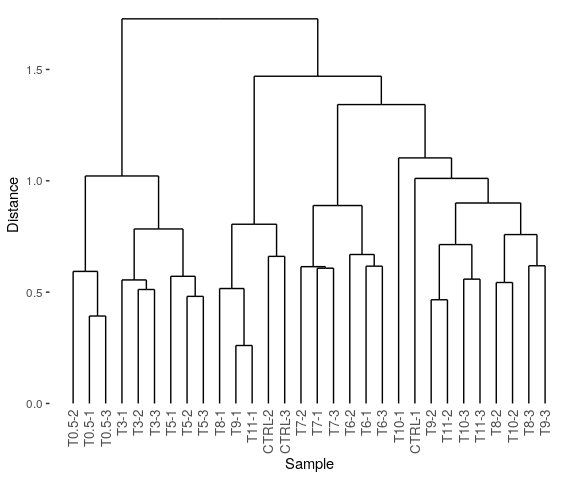

```r
plotClustering(prodat.norm)
```

# 4 Differential expression

These particular data come from a time-course experiment that would require analysis beyond *Proteus* package. We can however show how differential expression can be used to identify proteins changing between time points 0.5<sup>h</sup> and 8<sup>h</sup>.

```r
res <- limmaDE(prodat.norm, conditions=c("T0.5", "T8"))
```

The distribution of p-values looks fine.

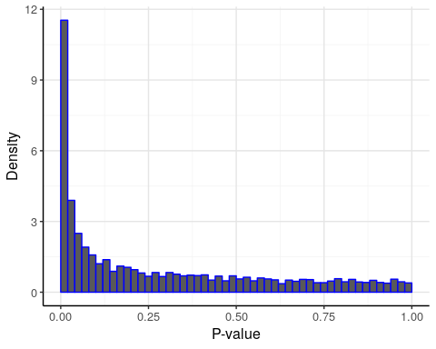

```r
plotPdist(res)
```

The top of the table of differentially expressed proteins:

```r
res <- res[order(res$adj.P.Val),]
head(res)
```

```
##             protein     logFC   AveExpr         t      P.Value
## 1417  Tb927.11.1030  2.830422 -4.129244  74.00862 7.726029e-11
## 1583 Tb927.11.12410  1.749682 -3.787771  38.09474 5.981584e-09
## 1130  Tb927.10.6330  2.367067 -3.989116  32.95518 1.541802e-08
## 1659  Tb927.11.1340  1.526537 -3.807683  30.91149 2.341458e-08
## 3650   Tb927.5.285b -1.499136 -3.068029 -31.22542 2.192074e-08
## 3898   Tb927.6.2070 -1.687678 -3.597221 -26.04447 7.150507e-08
##         adj.P.Val         B significant mean_T0.5   mean_T8 ngood_T0.5
## 1417 3.837519e-07 12.482381        TRUE -5.544455 -2.714033          3
## 1583 1.485526e-05 10.651477        TRUE -4.662612 -2.912930          3
## 1130 2.326005e-05 10.042550        TRUE -5.172649 -2.805583          3
## 1659 2.326005e-05  9.749585        TRUE -4.570952 -3.044415          3
## 3650 2.326005e-05  9.796774        TRUE -2.318461 -3.817597          3
## 3898 5.073795e-05  8.897958        TRUE -2.753382 -4.441060          3
##      ngood_T8
## 1417        3
## 1583        3
## 1130        3
## 1659        3
## 3650        3
## 3898        3
```

And the top protein from the table:

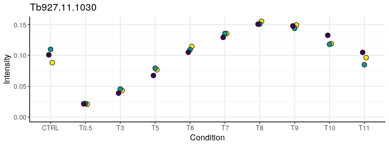

```r
prot <- as.character(res$protein[1])
plotIntensities(prodat.norm, id=prot)
```